# Young Men's Mental Wellbeing in the UK

## Introduction

This report analyses the state of young people's mental wellbeing in the UK. Using a varity of different aspects to gain a more holsitc picture of the mental wellbeing of young men and women. Aspects such as relational connections and community, satisifcation in leisure time and overall mental wellbeing. A key focus is to understand the state mental wellbeing of men in the UK and how this compares to women's, both recently and across the years.

My intrest in this area of men's mental wellbeing was sparked by one of my favourite UK music artists, Guvna B. In his most recent book, *Unspoken: Toxic Masculinity and How I Faced the Man Within the Man*, he offered a vulnerable perspective on his own journey with expressing his feelings and how as a man he found it harder to show weakness in his ubpringing and how this impacted his mental wellbeing. In his newest album, *The Village is on Fire*, he explores the need for community and people to reach out to when in need. These bodies of work resonnated with me and raised my interest in the topic of mental well-being for men in particualr, for myself and others. I began to be curious about how well, or not well, I prioritise my own well-being and decided to research how other people do as well.

Initially, we will provide context for our concept domain. Then data collection is described along justifications for my chosen dataset and an evaluation of its limitations. Afterwards, I will go into the analysis and results relating to my research questions, ending with an evaluation of the overall visualisation process.

## Research topic and context

### Topic definitions:

**Mental wellbeing**: "Mental wellbeing derives from psychological functioning, which includes the ability to develop and maintain mutually beneficial relationships, and from levels of happiness and contentment with life, usually measured as life satisfaction. Psychological functioning includes the ability to maintain a sense of autonomy, agency, self-acceptance, self-esteem, personal growth and purpose in life. Mental wellbeing is more than the outcome of treating or preventing mental illness." (Warwick-Edinburgh Mental Wellbeing Scale, 2006)

**Eudaimonic perspective**: An "Eudaimonic perspective of wellbeing focuses on psychological functioning, good relationships with others and self-realisation. This is the development of human potential that, when realised, results in positive functioning in life, and covers a wide range of cognitive aspects of mental health." (Warwick-Edinburgh Mental Wellbeing Scale, 2006)

**Warwick edinburgh mental wellbeing scale (WEMWBS)**:

- Overview : "The Warwick-Edinburgh Mental Wellbeing Scales were developed to enable the measuring of mental wellbeing in the general population and the evaluation of projects, programmes and policies which aim to improve mental wellbeing… The items are all worded positively and cover both feeling and functioning aspects of mental wellbeing, thereby making the concept more accessible. The scale has been widely used nationally and internationally for monitoring, evaluating projects and programmes and investigating the determinants of mental wellbeing."
- How it is used : "WEMWBS is a 14-item scale covering subjective wellbeing and psychological functioning, in which all items are worded positively and address aspects of positive mental health. The scale is scored by summing the response to each item answered on a 1 to 5 Likert scale. The minimum scale score is 14 and the maximum is 70. WEMWBS was initially validated for use in the UK with those aged 16 and above, involving surveys in both student and general population samples, and focus groups. It has now been widely validated in different populations and languages other than English."
- Origins : The Warwick–Edinburgh Mental Well-being Scale was funded by the Scottish Government National Programme for Improving Mental Health and Wellbeing, commissioned by NHS Health Scotland, developed by the University of Warwick and the University of Edinburgh, and is jointly owned by NHS Health Scotland, the University of Warwick and the University of Edinburgh. (Professor Stewart-Brown and Dr Janmohamed, 2015)

**Short Warwick edinburgh mental wellbeing scale (SWEMWBS)**: SWEMWBS is a short version of the Warwick-Edinburgh Mental Wellbeing Scale, containing a 7-item scale instead of the full 14.

**Leisure time satisfaction**: “positive perceptions or feelings that an individual forms, elicits, or gains as a result of engaging in leisure activities and choices. It is the degree to which one is presently content or pleased with her general leisure experiences and situations. This positive feeling of pleasure results from the satisfaction of felt or unfelt needs of the individual”. (Beard & Ragheb, 1980)

**Be there (for someone)**: Idiom, “to be available to provide help and support for someone.” (Cambridge Dictionary)

I hope to learn and understand a bit more about how connected men are relationally in the UK, what their mental wellbeing like on average and compare this to women. In my experience I have felt that men are socialised to negelct their emotions and not show weakness, asking for help; all things that impact our ability to cope and therefore our mental wellbeing.

I chose to narrow the scope to young people it is the age group relevent to me currently. It will be interesting to see how my ages mates handle their well-being. I also believe that if we understand the state of young peoples mental well-being we can inform the lives of our adults in the future.

The definition of mental wellbeing above informed my research questions:

### Research questions

1. **(R1)**: Firstly, what is the state of the overall mental-wellbeing of men and how does that compare to women?
2. **(R2)** Secondly, How connected are men? what is the quality of their relationships when it comes to them being in need, and how does this compare to women?
3. **(R3)** Lastly, how satisfied are men and women with their leisure time, are they satisfied with how they spend their time outside of work and other commitments?

R1 relates to the Questioniare on the SWEMWBS, R2 to the Questionaire on how much adults would agree they have someone there for them in time of need. Finally, R3 relates to the Questionaire on how satisfied men and women are with their lesiure times. I aim to look at mental-wellbeing in a holisitc sense, covering both how the people feel personally and their external circumstances.

## Data collection

The dataset was obtained from the Office of National Statistics (ONS) chosen because it focuses on mental well-being over mental health which is outside of my desired scope. I want to focus on exploring young people’s ability to function well and respond to external challenges as apposed to the presence or absence of mental illnesses.

This dataset also uses a trusted scale for mental wellbeing, the WEMWBS, which is specically designed to measure changes in mental well being. This is again opposed to other scales used in questionnaires that, while important, are designed to identify mental health disorders such as scizopherina, depression and suicide. The noticeable difference with the WEMBS scale is the focus on positivity, holistic growth and development, which has potential to be relevant wider range of young people; those dealing with mental health issues and those who are not. This scale being used made the dataset stick out to me.

Lastly, this specific dataset is not well reported on, there is space for me to explore this dataset.

When evaluating the data I noticed the suitablity of the questions asked, to the requirements of the report and my aforementioned definiton of mental-wellbeing. Requirements such as:

- the established WEMWBS to measure mental-wellbing,
- physical activity and leisure included as well as,
- measures on connectivity and relationships.
- The dataset also compared men and women.
- Additionally, it includes enough time series data to show changes

One limitiations of the dataset is that the time series data stopping before the COVID-19 pandemic, the dataset's most recent entry was March 2020. It would have been intresting to see how the pandemic impacted the mental-wellbeing, however, this might need to be its own dedicated study. Another limitation would be the data being edited in terms of averages and percentages. Not allowing us to have access to the raw data from these questioniares. This makes it harder to get detailed descriptive statistics.

## Data overview and pre-processing

The dataset contains a wide range of responses from young people across the UK to questions regarding their mental well-being. Due to this, the data composition is mostly ordinal categorical variables, likert scale responses, for example: Completely dissatisfied to Completely satisfied.

We do have other variable data types, such as the time series data. This is a quatitative interval data type used in almost every sheet, showing changes in responses over-time,. The variability of the time series is set to annual observations as a time span.

We also have ratio in the percentages and the SWEMWBS variable; The percentages show the proportion of responses to certain questions. And although SWEMWBS is a questionaire, the responses on the point-scale are totaled and calculated as a metric score, we have the average for each year. Laslty, we have genders as the only nominal variable.

Below is a table showing the variables, their data types and ranges:

[output not shown]

When reading the dataset using pandas I noticed a pattern of large amounts of graphics and notes made by the editor to explain the data. These were not neccessary to our investigation and needed to be efficently deleted to allow for analysis.

```python
#Cleaning and preparing my three dataframes for analysis

# Import libraries

import numpy as np
import matplotlib.pyplot as plt
import pandas as pd
import seaborn as sns
```

When cleaning the data, specically, handling blank space and metadata, I initally tried using pandas bulit-in functions such as `dropna` but this removed a lot of key data or rearranged the dataset. Extra information addded by the editor meant a lot of repeated cleaning steps were needed. To improve efficiency I created a function called `remove_na_values()` to remove all types of metadata across each of my required datasets.

`remove_na_values()` allows me to the repeated process of removing the inital blank spaces and colour graphics and focus on the key values. This is acheieved by removing the extra details, above, below and to the side of the orignal excell spreedsheets.

Values such as is `negative_bottom` are counted and then entered into the funtion.

More specifc and tailored data manipulation will be done afterwards.

```python
## User-defined function for inital data cleaning, refer back to for keyword arguments
# we use slicing with the given arguments to removed various repeated unnecessary values.

def remove_na_values(dataset, first_rows, last_column, middle_columns, negative_bottom ):

    # deleting the first set of rows of grpahics added by the editor to show overall change
    dataset.drop(index = dataset.index[0:first_rows], inplace = True)

    # removing all unnecessary columns from last_column onwards
    dataset.drop(columns=dataset.columns[last_column:], inplace = True)

    # check if there are middle columns to delete, if so remove them
    if middle_columns != None:
    # deleting formatting rows of blank space inbetween values
        dataset.drop(columns=middle_columns, inplace = True)


    # deleting the rows with editors notes at the bottom of the dataset
    dataset.drop(index=dataset.index[negative_bottom:], inplace=True)

    # Resetting the index back to zero to be more useful
    dataset.reset_index(drop=True,inplace=True)

    # Making the header to the likert scale options instead of 'Unnamed'
    dataset.columns = dataset.iloc[0]

    # Correcting a subscript error
    dataset.replace('2009-103', '2009-10', inplace = True)

    return dataset
```

#### Short WEMWBS Dataframe Inital Cleaning

```python
#  read dataset, short wemwbs sheet
s_wemwbs = pd.read_excel('ypreferencetables0920reformatted.xlsx', sheet_name = 7)
```

```python
# intial data cleaning function used on s_wemwbs dataframe using our custom cleaning function 'remove_na'

# we have chosen to delete the sample size column and the confidence intervals as we do not need that information right now
s_wemwbs = remove_na_values(s_wemwbs, 6, 2, None, -11)
```

```python
# we want the female results, across all years, for this questionnaire on the wemwbs stored in a seperate dataframe
s_wemwbs_female = s_wemwbs.iloc[10:13]
```

```python
# Resetting the index in this new dataframe from 31 back to 0 to be more useful

s_wemwbs_female.reset_index(drop = True, inplace = True)

# prepared dataset for womens swemwbs results
s_wemwbs_female.head()
```

|  | NaN | Mean score\n out of 35 |
| --- | --- | --- |
| 0 | 2015-16 | 24.6 |
| 1 | 2012-13 | 23.8 |
| 2 | 2009-10 | 24.7 |

```python
# we want the male results, across all years, for this questionnaire on the wemwbs stored in a seperate dataframe
# male results run from the 16th index onwards
s_wemwbs_male = s_wemwbs.iloc[16:]
```

```python
# Resetting the index back to 0 to be more useful


s_wemwbs_male.reset_index(drop = True, inplace = True)

# prepared dataset for mens swemwbs results
s_wemwbs_male
```

|  | NaN | Mean score\n out of 35 |
| --- | --- | --- |
| 0 | 2015-16 | 25.7 |
| 1 | 2012-13 | 24.6 |
| 2 | 2009-10 | 25.3 |

#### Leisure Satisfaction Dataframe Inital Cleaning

```python
# read dataset, leisure satisfaction sheet
leisure_time = pd.read_excel('ypreferencetables0920reformatted.xlsx', sheet_name = 16, parse_dates=True)
```

```python
# intial data cleaning function used on leisure_time dataframe

# Noteably, we have removed 'Mostly or completely satisfied' from the dataframe as it is the combination of the top two satisfied categories, which can skew data
leisure_time = remove_na_values(leisure_time, 7, 11, ['Unnamed: 1', 'Unnamed: 2', 'Unnamed: 3'], -7)
```

```python
# we want the female results for this questionare on leisure satisfaction across all years
# female results across the years run from the 19th index to the 27th
leisure_satisfaction_female = leisure_time.iloc[19:28]
```

```python
# Resetting the index from 19 back to 0 to be more useful
leisure_satisfaction_female.reset_index(drop = True, inplace = True)

## prepared dataset for womens leisure satisifaction results
leisure_satisfaction_female
```

|  | NaN | Completely satisfied | Mostly satisfied | Somewhat satisfied | Neither satisfied nor dissatisfied | Somewhat dissatisfied | Mostly dissatisfied | Completely dissatisfied |
| --- | --- | --- | --- | --- | --- | --- | --- | --- |
| 0 | 2017-18 | 12.1 | 24.5 | 25.7 | 15.2 | 14.3 | 6.4 | 2 |
| 1 | 2016-17 | 13 | 26.3 | 22.2 | 15 | 14.1 | 6.9 | 2.6 |
| 2 | 2015-16 | 14.1 | 27.8 | 24.1 | 12.7 | 12.5 | 6.6 | 2.2 |
| 3 | 2014-15 | 11.8 | 26.1 | 24.2 | 13.6 | 14.7 | 6.8 | 2.8 |
| 4 | 2013-14 | 12.7 | 27.1 | 18.7 | 14.8 | 14.9 | 8.9 | 2.8 |
| 5 | 2012-13 | 11.6 | 25.5 | 19.6 | 14.2 | 14.8 | 9.6 | 4.8 |
| 6 | 2011-12 | 9.9 | 26.6 | 21 | 14.8 | 14.5 | 10 | 3.2 |
| 7 | 2010-11 | 12.7 | 27.2 | 22.5 | 14 | 14.7 | 6.8 | 2.2 |
| 8 | 2009-10 | 12.8 | 25 | 21.6 | 15.3 | 15.1 | 6.7 | 3.6 |

```python
# we want the male results for this questionare on leisure satisfication across all years
# male results across the years run from the 31st index to the 39th
leisure_satisfaction_male = leisure_time.iloc[31:40]
```

```python
# # Resetting the index from 31 back to 0 to be more useful

leisure_satisfaction_male.reset_index(drop = True, inplace = True)

# prepared dataset for mens leisure satisifaction results
leisure_satisfaction_male
```

|  | NaN | Completely satisfied | Mostly satisfied | Somewhat satisfied | Neither satisfied nor dissatisfied | Somewhat dissatisfied | Mostly dissatisfied | Completely dissatisfied |
| --- | --- | --- | --- | --- | --- | --- | --- | --- |
| 0 | 2017-18 | 19.1 | 31.1 | 18.5 | 14.9 | 8.9 | 5.1 | 2.4 |
| 1 | 2016-17 | 22 | 30.8 | 20.2 | 11.4 | 9.4 | 3.8 | 2.5 |
| 2 | 2015-16 | 22.5 | 29.6 | 18.2 | 12.7 | 9.6 | 5.3 | 2 |
| 3 | 2014-15 | 19 | 29.2 | 19.7 | 12.8 | 10.5 | 5.9 | 2.9 |
| 4 | 2013-14 | 18.4 | 28.6 | 20 | 13.1 | 11.5 | 5.6 | 2.8 |
| 5 | 2012-13 | 19.6 | 26.5 | 17.7 | 14.2 | 12.7 | 6.1 | 3.2 |
| 6 | 2011-12 | 18.1 | 28.1 | 20.1 | 12.4 | 12.4 | 5.7 | 3.2 |
| 7 | 2010-11 | 18.4 | 28.7 | 21.5 | 12.2 | 12.3 | 4.7 | 2.3 |
| 8 | 2009-10 | 17.3 | 27 | 23.2 | 13.6 | 10.2 | 5.5 | 3.1 |

#### 'There for you' Dataframe Inital Cleaning

```python
# read dataset, There for you questionaire sheet
there_for_you = pd.read_excel('ypreferencetables0920reformatted.xlsx', sheet_name = 8)
```

```python
# intial data cleaning function used on there_for_you dataframe
# contains all results without graphics and metadata

there_for_you = remove_na_values(there_for_you, 7, 7, ['Unnamed: 1', 'Unnamed: 3'], -8)
```

```python
# we want the male and female results for this question on those 'there for you' only for the year 2018-19

# NOTE: As there is only one entry per gender,
# the first data point[11] is the female result and the second data point[17] is the male

there_for_you = there_for_you.iloc[[11,17]]
there_for_you
```

|  | NaN | Definitely agree | Tend to agree | Tend to disagree | Definitely disagree |
| --- | --- | --- | --- | --- | --- |
| 11 | 2018-19 | 74 | 21.7 | 3.4 | 0.9 |
| 17 | 2018-19 | 66.9 | 30 | 2.6 | 0.5 |

```python
# Resetting the index back to 0 to be more useful
# NOTE: the first data point[0] is the female result and the second data point[1] is the male


there_for_you.reset_index(drop = True, inplace = True)
there_for_you
```

|  | NaN | Definitely agree | Tend to agree | Tend to disagree | Definitely disagree |
| --- | --- | --- | --- | --- | --- |
| 0 | 2018-19 | 74 | 21.7 | 3.4 | 0.9 |
| 1 | 2018-19 | 66.9 | 30 | 2.6 | 0.5 |

## Analysis and results

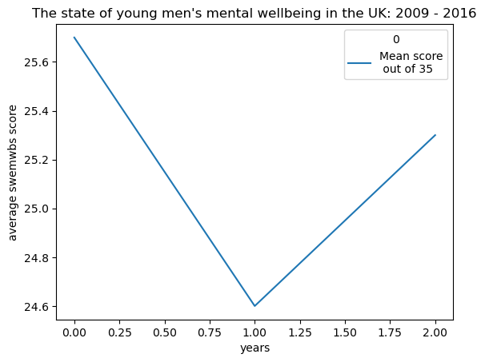

```python
s_wemwbs_male.plot(title="The state of young men's mental wellbeing in the UK: 2009 - 2016",
                   ylabel= 'average swemwbs score',
                   xlabel= 'years')
```

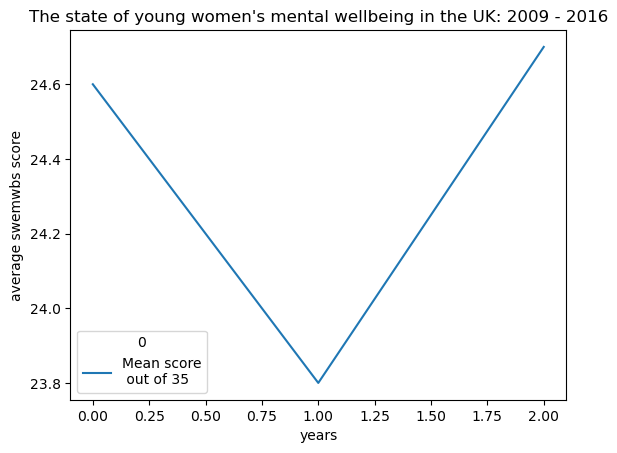

```python
s_wemwbs_female.plot(title="The state of young women's mental wellbeing in the UK: 2009 - 2016",
                   ylabel= 'average swemwbs score',
                   xlabel= 'years')
```

```
No artists with labels found to put in legend.  Note that artists whose label start with an underscore are ignored when legend() is called with no argument.
```

[figure not shown]

```python
fig = plt.figure()
ax = fig.add_subplot()

#ax.plot(s_wemwbs_male.index, s_wemwbs_male, color = '#8724f5', fmt= '.-')
#ax.plot(data= s_wemwbs_female, color= '#f0ad2f', '.-')

ax.set(title= "The state of young peopel's mental wellbeing in the UK: 2009 - 2016",
       ylabel= 'average swemwbs score',
       xlabel= 'years')
ax.legend()

plt.show()
```

```python
leisure_satisfaction_female
```

|  | NaN | Completely satisfied | Mostly satisfied | Somewhat satisfied | Neither satisfied nor dissatisfied | Somewhat dissatisfied | Mostly dissatisfied | Completely dissatisfied |
| --- | --- | --- | --- | --- | --- | --- | --- | --- |
| 0 | 2017-18 | 12.1 | 24.5 | 25.7 | 15.2 | 14.3 | 6.4 | 2 |
| 1 | 2016-17 | 13 | 26.3 | 22.2 | 15 | 14.1 | 6.9 | 2.6 |
| 2 | 2015-16 | 14.1 | 27.8 | 24.1 | 12.7 | 12.5 | 6.6 | 2.2 |
| 3 | 2014-15 | 11.8 | 26.1 | 24.2 | 13.6 | 14.7 | 6.8 | 2.8 |
| 4 | 2013-14 | 12.7 | 27.1 | 18.7 | 14.8 | 14.9 | 8.9 | 2.8 |
| 5 | 2012-13 | 11.6 | 25.5 | 19.6 | 14.2 | 14.8 | 9.6 | 4.8 |
| 6 | 2011-12 | 9.9 | 26.6 | 21 | 14.8 | 14.5 | 10 | 3.2 |
| 7 | 2010-11 | 12.7 | 27.2 | 22.5 | 14 | 14.7 | 6.8 | 2.2 |
| 8 | 2009-10 | 12.8 | 25 | 21.6 | 15.3 | 15.1 | 6.7 | 3.6 |

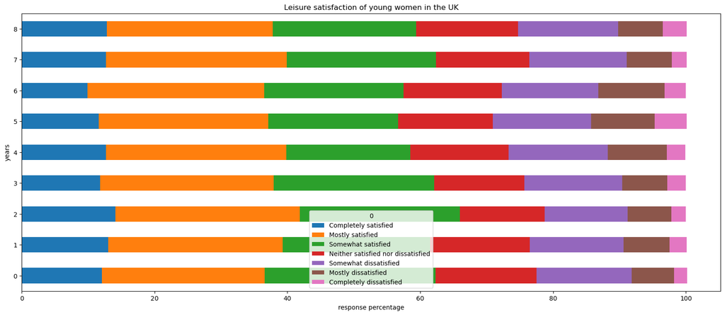

```python
leisure_satisfaction_female.plot.barh(figsize=(20,8), stacked= True,
                                      title="Leisure satisfaction of young women in the UK",
                                    xlabel= 'response percentage',
                                    ylabel= 'years' )
```

```python
leisure_satisfaction_male
```

|  | NaN | Completely satisfied | Mostly satisfied | Somewhat satisfied | Neither satisfied nor dissatisfied | Somewhat dissatisfied | Mostly dissatisfied | Completely dissatisfied |
| --- | --- | --- | --- | --- | --- | --- | --- | --- |
| 0 | 2017-18 | 19.1 | 31.1 | 18.5 | 14.9 | 8.9 | 5.1 | 2.4 |
| 1 | 2016-17 | 22 | 30.8 | 20.2 | 11.4 | 9.4 | 3.8 | 2.5 |
| 2 | 2015-16 | 22.5 | 29.6 | 18.2 | 12.7 | 9.6 | 5.3 | 2 |
| 3 | 2014-15 | 19 | 29.2 | 19.7 | 12.8 | 10.5 | 5.9 | 2.9 |
| 4 | 2013-14 | 18.4 | 28.6 | 20 | 13.1 | 11.5 | 5.6 | 2.8 |
| 5 | 2012-13 | 19.6 | 26.5 | 17.7 | 14.2 | 12.7 | 6.1 | 3.2 |
| 6 | 2011-12 | 18.1 | 28.1 | 20.1 | 12.4 | 12.4 | 5.7 | 3.2 |
| 7 | 2010-11 | 18.4 | 28.7 | 21.5 | 12.2 | 12.3 | 4.7 | 2.3 |
| 8 | 2009-10 | 17.3 | 27 | 23.2 | 13.6 | 10.2 | 5.5 | 3.1 |

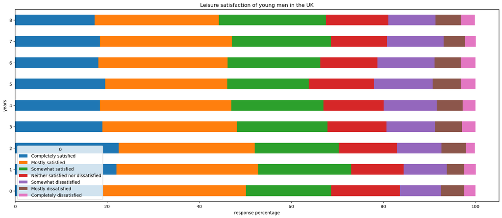

```python
leisure_satisfaction_male.plot.barh(figsize=(20,8), stacked= True,
                                    title="Leisure satisfaction of young men in the UK",
                                    xlabel= 'response percentage',
                                    ylabel= 'years')
```

### There for you

```python
there_for_you
```

|  | NaN | Definitely agree | Tend to agree | Tend to disagree | Definitely disagree |
| --- | --- | --- | --- | --- | --- |
| 0 | 2018-19 | 74 | 21.7 | 3.4 | 0.9 |
| 1 | 2018-19 | 66.9 | 30 | 2.6 | 0.5 |

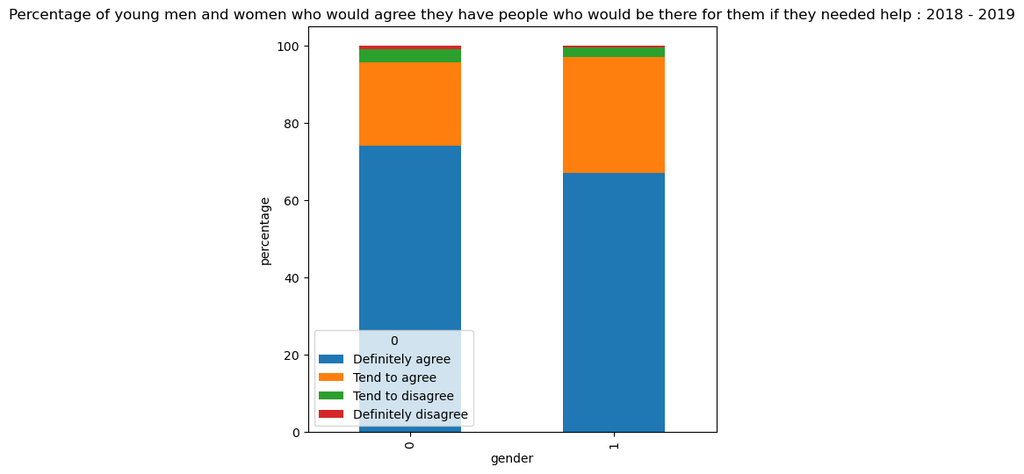

```python
there_for_you.plot.bar(figsize=(6,6) , stacked= True,
                       title="Percentage of young men and women who would agree they have people who would be there for them if they needed help : 2018 - 2019",
                   ylabel= 'percentage',
                   xlabel= 'gender')
```

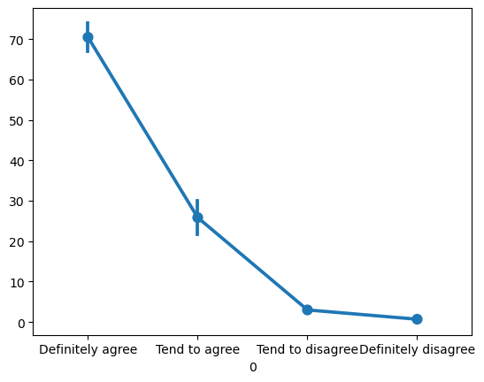

```python
sns.pointplot(data=there_for_you

             )
```

Our main data questions for this visualisation was

- how many young men feel like they have someone to rely on?
- how does this compare to women in the same age range?

I choose to use a stacked bar chart, as the chart type that is often used when comparing nomial cateogories (in our example, male and female). The stacked bar chart is also suitable to the nature of our data, containing likert scale responses, categorical ordinal variables. The reader can see the logical sequence of responses. In addition, stacked bars helps show the responses as a percentage in a clear and concise way. The tone in this visualisation was more emotive, with a focus on the visual difference in responses over high accuracy, which is another reason for this bar chart design choice. (kirk 2012)

## Conclusions

#### Key findings

- Over time men and womens overall health is similar
- Men seem more satisified with leisure than women
- There is a slight gap in terms of connectivity of men and women, favouring women. This might spark more research and study into solutions to reduce this gap and help young men be more connected.

#### Evaluation of visualisations and overall process

When it came to data acquistion, I found a dataset that ultised the measurement for mental wellbeing that I desired however I was not aware at the time that the dataset I used comprised of averages of the raw data found in a seperate dataset. The focus of the dataset was to show changes in attiudes of young people over time. This restricted me in terms of making my own observations. If I was to do this assingment again, I would have found the dataset closest to the raw data. I did end up finding this dataset, but far to late in the report process to ultise.

Secondly, I learnt the importance of data cleaning, a lot of my plans for visualisations were limited by poor labeling, indexing and incorrect typing of data. Having the data clean and semanitcally accurate would have helped me to visualise with more creatvie freedom, allowing me to reach my design requirements. Especially as my visualisation tool, pandas, assumes tidy data.

## References

##### Data Visualisation

- Kirk, A. (2012). Data visualization a successful design process: A structured design approach to equip you with the knowledge of how to successfully accomplish any data visualization challenge efficiently and effectively. Birmingham : Packt Publishing.
- McKinney, W. (2017). Python for data analysis: Data wrangling with pandas, NumPy, and IPython (Second edition..). O’Reilly.
- Yau, N. (2013). Data points visualization that means something. Wiley.

#### Mental Wellbeing

- Office of National Statistics. (2020). Young People's wellbeing measures.
- Information for 11-18 year olds on looking after your wellbeing. (n.d.). Retrieved 9 May 2023, from https://www.mind.org.uk/for-young-people/looking-after-yourself/looking-after-your-wellbeing/

##### Warwick-Edinburgh Mental Well-being Scale (WEMWBS) User guide

- NHS Scotland. (2015). Warwick-Edinburgh Mental Well-being Scale (WEMWBS) User guide – Version 2.
- The Warwick-Edinburgh Mental Wellbeing Scale (WEMWBS). (n.d.). from https://warwick.ac.uk/fac/sci/med/research/platform/wemwbs

##### Coding

- NumPy Reference—NumPy v1.24 Manual. (n.d.). Retrieved 9 May 2023, from https://numpy.org/doc/stable/reference/?v=20230508212814
- pandas documentation—Pandas 2.0.1 documentation. (n.d.). Retrieved 9 May 2023, from https://pandas.pydata.org/pandas-docs/stable/?v=20230508212814
- Users guide—Matplotlib 3.7.1 documentation. (n.d.). Retrieved 9 May 2023, from https://matplotlib.org/stable/users/index.html

## Word Count

The following code will count the number of words in Markdown cells. Code cells are not included.

- `Main word count` is the number of words in the main body of the text, *excluding* references or appendices.
- `References and appendices word count` is the number of words in any references or appendices.

Only `Main word count` relates to the assignment word limit. There is no limit to the number of words that can be included in references or appendices. Please note that appendices should only be used to provide context or supporting information. *No marks will be directly awarded for material submitted in appendices*.

Important:

- Please do not modify the word count code!
- To exclude references from your word count **you must** have a cell that starts with the text `## References`. Everything below this cell will not count towards the main word count.
- If you are submitting additional material as appendices **you must** have a cell that starts with the text `## Appendices`. Everything below this cell will not count towards the main word count. If you do not have any appendices you can delete the `## Appendices` cell.
- Code comments should only be used to explain details of the implementation, not for discussing your findings. All analysis commentary **must** be written in Markdown cells. *No marks will be awarded for analysis discussion submitted as comments in code cells*.

```python
%%js

// Run this cell to update your word count.

function wordcount() {
    let wordCount = 0
    let extraCount = 0
    let mainBody = true

    let cells = Jupyter.notebook.get_cells()
    cells.forEach((cell) => {
        if (cell.cell_type == 'markdown') {
            let text = cell.get_text()
            // Stop counting as main body when get to References or Appendices.
            if (text.startsWith('## References') ||
                text.startsWith('## Appendices')) {
                mainBody = false
            }
            if (text.startsWith('## Word Count')) {
                text = ''
            }
            if (text) {
                let words = text.toLowerCase().match(/\b[a-z\d]+\b/g)
                if (words) {
                    let cellCount = words.length
                    if (mainBody) {
                        wordCount += cellCount
                    } else {
                        extraCount += cellCount
                    }
                }
            }
        }
    })
    return [wordCount, extraCount]
}

let wc = wordcount()
element.append(`Main word count: ${wc[0]} (References and appendices word count: ${wc[1]})`)
```